Review

Effects of aerobic exercise on ﬁbroblast growth factor 21 in overweight

and obesity. A systematic review

María Porﬂitt-Rodríguez <sup>a</sup>, Valentina Guzmán-Arriagada <sup>a</sup>, Romina Sandoval-Valderrama <sup>a</sup>, Charmaine S. Tam <sup>b</sup>,

Francisca Pavicic <sup>c</sup>, Pamela Ehrenfeld <sup>c</sup><sup>,</sup><sup>d</sup>, Sergio Martínez-Huenchullán <sup>d</sup><sup>,</sup><sup>e</sup><sup>,</sup><sup>f</sup><sup>,</sup>⁎

a School of Physical Therapy, Faculty of Medicine, Universidad Austral de Chile, Valdivia, Chile

b Faculty of Medicine and Health, University of Sydney, Sydney, Australia

c Laboratory of Cellular Pathology, Institute of Anatomy, Histology & Pathology, Faculty of Medicine, Universidad Austral de Chile, Valdivia, Chile

d Centro Interdisciplinario de Estudios del Sistema Nervioso (CISNe), Chile

e Locomotor Apparatus and Rehabilitation Institute, Faculty of Medicine, Universidad Austral de Chile, Valdivia, Chile

f Cardiorespiratory and Metabolic Function Laboratory – Neyün, Faculty of Medicine, Universidad Austral de Chile, Valdivia, Chile

a b s t r a c t

a r t i c l e

i n f o

Article history:

Received 7 September 2021

Accepted 10 January 2022

Fibroblast growth factor 21 (FGF21) has been suggested to improve metabolism during aerobic exercise in obe-

sity. However, the variability of exercise interventions gives rise to discrepancies in the ﬁeld. Therefore, we aimed

to systematically review the available literature regarding the effects of aerobic exercise on FGF21 in the context

of overweight and obesity. Our search included original articles published between 2009 and November 2021

found in PubMed, Science Direct, and Medline. Clinical and preclinical studies were included. Studies, where sub-

jects or animals presented with other conditions (e.g., cancer, stroke), were excluded. From an initial 43 studies,

19 (clinical studies = 9; preclinical studies = 10) were eligible for inclusion in this review. The main ﬁndings

were that acute exercise tended to increase circulatory levels of FGF21. In contrast, chronic exercise programs

(≥4 weeks) had the opposite effect along with inducing mRNA and protein increases of FGF receptors and β-

klotho in adipose tissue, liver, and skeletal muscle. In conclusion, both clinical and preclinical studies showed

that aerobic exercise exerts changes in circulatory and tissue FGF21, along with its receptors and co-receptor. Fu-

ture research is needed to elucidate the mechanisms, along with the physiological and clinical implications of

these changes.

© 2022 Elsevier Inc. All rights reserved.

Keywords:

Exercise

Fibroblast growth factor 21

Overweight

Obesity

1. Introduction

Obesity is a global health problem characterized by an increase in

adipose tissue depots, and contributing to the development of hyper-

tension, insulin resistance, and type 2 diabetes [1]. In recent decades,

scientiﬁc efforts have focused on ﬁnding speciﬁc mediators behind

this relationship, designing effective therapeutic strategies and/or inter-

ventions [2].

Such mediators include ﬁbroblast growth factor 21 (FGF21), which

was ﬁrst described in 2000 in the liver and thymus of mouse embryos

[3]. In 2005, the metabolic functions were described such as increasing

glucose uptake in adipocytes [4]. FGF21 is a protein with a small molec-

ular weight (~20 kDa) and recognized as a key factor in energy homeo-

stasis, given its ability to regulate glucose uptake [5] (in conjunction

with insulin), stimulate fatty acid oxidation, and inhibit lipogenesis.

Comprehensive reviews regarding FGF21 function are published else-

where [6–9]. Brieﬂy, FGF21 exerts its actions through binding with

FGF receptors (FGFR1 and FGFR2), along with its obligate coreceptor

β-klotho (KLB). In the absence of FGF21, FGFRs and KLB (present in

the plasmatic membrane) bind to each other forming a 1:1

heterocomplex, however, in the presence of FGF21, FGFRs form a homo-

dimer, establishing a 1:2 heterocomplex with KLB [10] changes that

trigger its signalling cascade (Fig. 1). Therefore, FGF21 can act in tissues

where FGFR and KLB are present, such as white adipose tissue, skeletal

muscle, heart, pancreas, and brown adipose tissue [7]. Normally, the

concentration of circulating FGF21 is low, however, stimuli such as

fasting, stress, and metabolic disorders increase its expression and se-

cretion mainly by the liver. However, FGF21 is also expressed in adipose

Metabolism Clinical and Experimental 129 (2022) 155137

Abbreviations: FGF21, ﬁbroblast growth factor 21; FGFR, ﬁbroblast growth factor

receptor; KLB, β-klotho; Akt, protein kinase B; VO2 peak, peak oxygen consumption;

OLEFT, Otsuka Long-Evans Tokushima Fatty; mRNA, messenger ribonucleic acid; HIIT,

high-intensity interval training; MICT, moderate-intensity constant training; MAPK,

mitogen-activated protein kinase; ERK, extracellular response-stimulated kinase; PI3K,

phosphatidylinositol 3-OH kinase; HbA1c, glycated hemoglobin; PGC-1α, peroxisome

proliferator-activated receptor gamma coactivator 1-alpha; HCC, hepatocellular carci-

noma; NAFLD, non-alcoholic fatty liver disease; HFD, high-fat diet; TGR5, G-protein-

coupled bile acid receptor; BMI, body mass index.

⁎ Corresponding author at: Rudloff 1650, Valdivia, Chile.

E-mail address: sergio.martinez@uach.cl (S. Martínez-Huenchullán).

[figure not shown]

https://doi.org/10.1016/j.metabol.2022.155137

0026-0495/© 2022 Elsevier Inc. All rights reserved.

[figure not shown]

Contents lists available at ScienceDirect

Metabolism Clinical and Experimental

journal homepage: www.metabolismjournal.com

tissue, skeletal muscle, brain, and pancreas being classiﬁed as a myok-

ine, adipokine, and hepatokine [11–13]. In that context, higher circulat-

ing FGF21 levels have been consistently reported in subjects with

obesity [14] and type 2 diabetes [15], changes that have nurtured the

hypothesis of the development of a FGF21 resistant state [16]. The

mechanism behind this condition is elusive [17]; however, the down-

regulation of FGFR and KLB in insulin-sensitive tissues has been pro-

posed [18].

As a therapy against obesity-related metabolic disorders, the bene-

ﬁts of physical activity and exercise are well-described [19]. However,

studies that examine the mechanisms behind those beneﬁts are limited.

There is emerging evidence that has investigated the effects of exercise

on FGF21 levels and signalling pathways. For instance, Tanimura et al.

investigated the acute effects of one exercise session on FGF21 levels

in lean humans and mice. Interestingly, they found that aerobic exercise

increased serum FGF21 concentration in both humans and mice. More-

over, increases in mRNA and protein FGF21 levels were seen in the liver

and gastrocnemius muscle of mice, ﬁndings that were associated with

higher levels of pAkt/Akt levels in muscle [20], suggesting that these

changes are functionally relevant, particularly from a glucose uptake

point of view. However, when exercise and FGF21 have been investi-

gated in obesity and metabolic dysfunction, the outcomes differ. Indeed,

Slusher et al. found a ~20% increase in circulating FGF21 in subjects with

obesity after one exercise session [21]. However, Yang et al. described

opposite results (>50% decrease in plasma FGF21) after 12 weeks of ex-

ercise training in overweight participants [22]. Furthermore, others

have failed to describe any changes in FGF21 levels whatsoever [23–25].

Therefore, considering the discrepancies in terms of results from the

studies in the ﬁeld, this study aims to systematically review the evi-

dence regarding the effects of aerobic exercise on FGF21 levels in the

context of overweight/obesity, to identify the available knowledge in

this ﬁeld, as well as the gaps that could direct the intention of future

studies.

2. Methods

Literature searches were conducted in three databases: PubMed,

ScienceDirect, and Medline. Original articles published between 2009

and November 2021, written in English, were considered. Eligible stud-

ies included preclinical studies that used obesity models and clinical

studies that included participants with overweight, obesity or type 2 di-

abetes between 18 and 60 years old. Studies where other associated

conditions were included, such as cancer, heart failure, or stroke were

excluded.

Searches were conducted as follows: PubMed: “Exercise” [Mesh]

AND “Fibroblast growth factor 21” [Supplementary concept] AND

“Overweight” [Mesh]; Science Direct: (Exercise OR physical activity

OR aerobic exercise) AND (FGF21 OR FGF-21 OR ﬁbroblast growth fac-

tor) AND (overweight OR Obesity); MEDLINE: (MM “Exercise+”) AND

“ﬁbroblast growth factor 21” AND (MM “Overweight+”),

3. Results

From an initial 43 studies found, 19 articles were included in this re-

view, from which 9 were clinical and 10 preclinical, as described in

Fig. 2. It is worth mentioning that one study was added by bibliography

search [26]. To facilitate the interpretation of the results from the se-

lected studies, these were further classiﬁed depending on whether the

exercise effects studied were acute (only one exercise session) or

chronic (longer than 4 weeks of training).

3.1. Clinical studies

From the 9 studies included, 4 were focused on the acute effects of

exercise on FGF21 levels (one exercise session), whereas 5 involved ex-

ercise training programs lasting between 5 and 12 weeks, with a pre-

scription ranging from 3 to 5 times/week. In 6 studies, the participants

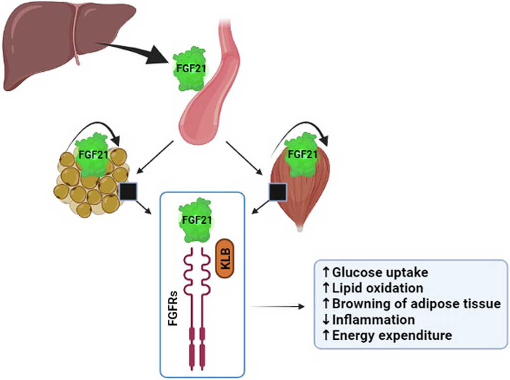

Fig. 1. Summary of FGF21 sources and its metabolic functions. FGF21 is mainly secreted by the liver into the circulation. There, it can act in tissues where FGFRs and its co-receptor KLB are

present, such as adipose tissue and skeletal muscle. These tissues, also have the ability to produce FGF21 in an autocrine/paracrine manner, to further induce its metabolic functions, such as

regulating glucose uptake, lipid oxidation, browning of adipose tissue, inﬂammation, and energy expenditure. FGF21: ﬁbroblast growth factor 21; FGFRs: ﬁbroblast growth factor

receptors; KLB: β-klotho. Figure created in BioRender.com.

Metabolism Clinical and Experimental 129 (2022) 155137

2

were classiﬁed as healthy and sedentary overweight/obese, whereas in

three of them, subjects with overweight/obesity and type 2 diabetes

were included.

For studies examining the acute effects of exercise on FGF21, two

studies found a plasma FGF21 increase levels of about 20% compared

vastus lateralis FGF21 mRNA levels [27]. In contrast, two studies that

cycle ergometer) did not ﬁnd any signiﬁcant changes [24,28].

For studies examining the chronic effects of exercise on FGF21, only

one reported a signiﬁcant change in plasma FGF21 where its levels de-

creased by over 50% compared to pre-training levels [22]. The clinical

studies included in this review are listed in Table 1.

3.2. Preclinical studies

All the preclinical studies included in this review (n = 10) focused

on investigating the chronic effects of exercise, where training programs

lasted from 4 to 36 weeks. Four out of 10 studies in this category in-

ilar to “physical activity” with its lack of prescription (e.g. intensity,

duration). Animals used in these studies were mostly C57BL/6 mice

the mice strain [31].

wheel running. Two studies compared different exercise regimes

(high-intensity interval training (HIIT) vs moderate-intensity constant

training (MICT)), ﬁnding similar effects on circulating FGF21 between

training regimes [26,35]. However, Xiong et al. analyzed FGF21 local tis-

sue changes after HIIT and MICT, ﬁnding that the latter induced

transcriptional increases in the liver, brown adipose tissue, and quadri-

ceps. Also, a ~3.5-fold increase in FGF21 protein was seen in brown ad-

ipose tissue [35]. 40% (4/10) of studies also described exercise-induced

increases in transcriptional and translational levels of FGFR1, FGFR2,

and/or KLB in the liver, epididymal fat, brown adipose tissue, and

skeletal muscle [29,33,35,36]. The preclinical studies included in this re-

view, which reported chronic exercise training effects in murine

models, are listed in Table 2.

A summary of the results presented here is described in Fig. 3.

4. Discussion

This systematic review aimed to analyze the available evidence, in

clinical and preclinical studies, regarding the effects of aerobic exercise

on FGF21 in the context of metabolic disease. The main ﬁndings indicate

that the FGF21 response against exercise depends on several factors,

such as length of intervention (acute vs chronic) and where FGF21

was measured (circulation vs tissues). Remarkable, single exercise ses-

sions were sufﬁcient to increase circulatory FGF21 levels. However,

studies involving exercise training programs (mostly preclinical) re-

ported decreases in plasma/serum FGF21, decreases in the transcrip-

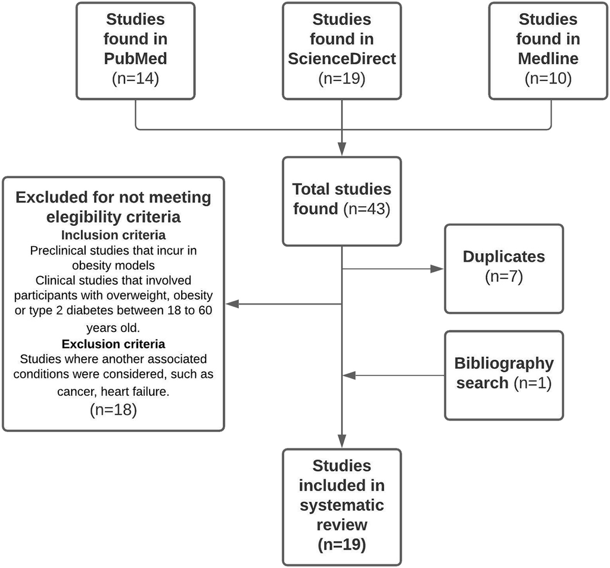

Fig. 2. Flowchart of search and article selection.

Metabolism Clinical and Experimental 129 (2022) 155137

3

In terms of exercise training protocols, the most recurrent modalities in

clinical studies were treadmill running and cycling, with 1 (acute) or

3–5 sessions per week (chronic), 30–60 min per session, from 5 to

12 weeks. In preclinical studies (mice or rats), only chronic effects of ex-

ercise were investigated, where voluntary wheel and treadmill running

were the most recurrent modalities, 2–5 sessions per week, 20–60 min

per session, from 4 to 36 weeks.

Since it was ﬁrst described, FGF21 has gained attention from the sci-

entiﬁc community given its role in energy homeostasis by, for instance,

promoting free fatty acid oxidation and glucose tolerance [3,4]. There-

fore, results described from early studies regarding the FGF21 levels in

the context of obesity were somewhat surprising. Zhang et al. in 2008

were one of the ﬁrst to describe higher circulatory FGF21 levels in sub-

jects with overweight/obesity, compared to normal-weight controls.

Moreover, these results were consistent with the ~3–4 fold increases

in Fgf21 mRNA levels in liver and adipose tissue of db/db mice [14], sug-

gesting that this response might be compensatory for the obesity/

related metabolic disturbances, or a sign for possible FGF21 resistance

development, a hypothesis which was subsequently conﬁrmed by

Fisher et al. proposing that obesity promoted a FGF21 resistant state

[16]. More recent studies in animal models have described that subcuta-

neous injections with recombinant human FGF21 were enough to im-

prove glucose tolerance in HFD-fed mice [38], highlighting that further

increases in circulating levels of FGF21 levels during obesity might still

confer metabolic beneﬁts. Interestingly, signiﬁcant increases of circulat-

ing, skeletal muscle, and liver FGF21, has been previously described in

lean mice and humans after a single exercise bout [20], ﬁndings that

are concurrent with the results reported in two different studies in-

cluded in this review, where a ~20% increase in FGF21 circulatory levels

in humans after a single session of aerobic exercise at a moderate inten-

sity [21,27], changes that were concurrent with FGF21 mRNA increases

in vastus lateralis muscle [27]. This could indicate that even when obe-

sity triggers a compensatory metabolic response by increasing FGF21

secretion, exercise can induce a summative response. The physiological

implications/relevance of these changes is still unknown, given that no

concurrent signalling pathway measurements (e.g. MAPK, ERK, Akt-

Table 1

Clinical studies (n = 9).

A/C

Authors

Year

Participants

Exercise program

Changes in FGF-21

Secondary outcomes

A

Slusher

et al. [21]

2015

24 healthy and sedentary men and

women.

Mean age: 22.7 years old.

Mean BMI: 35.5 kg/m<sup>2</sup>

Treadmill

One session of 30 min at 75% of VO2max

↑ Plasma (1.2-fold)

↑ Plasma IL-6 (1.2-fold)

A

Sargeant

et al. [28]

2017

11 healthy, sedentary, or moderately

active men and women.

Mean age: 45 years old.

Mean BMI: 29.2 kg/m<sup>2</sup>

Treadmill.

One session of 60 min at 60% of VO2peak.

↔ Plasma

↔ Plasma follistatin

↔ Plasma LECT2

↔ Fetuin A

A

Sabaratnam

et al. [27]

2018

13 males with type 2 diabetes

without complications.

Mean age: 55.4 years old.

Mean BMI: 29.7 kg/m<sup>2</sup>

Cycle ergometer.

One session of 60 min at 70% of VO2max.

↑ Vastus lateralis

mRNA (~1.5-fold)

↑ Plasma

(~1.2-fold)

↓ Plasma (0.75-fold

3 h post-exercise)

↑ Vastus lateralis IL-6 mRNA

(~50-fold)

↑ Plasma IL-6 (3.5-fold)

↑ Vastus lateralis ANGPTL4 mRNA

(6-fold and 12-fold at 3 h recovery)

↑ Plasma ANGPTL4 (1.2-fold and

2-fold at 3 h recovery)

↑ Vastus lateralis CYR61 mRNA

(5-fold)

A

Garneau

et al. [24]

2020

11 healthy and sedentary women.

Mean age: 30.0 years old.

Mean BMI: 35.4 kg/m<sup>2</sup>

Cycle ergometer

60 min at 60% VO2peak

↔ Plasma

↑ IL-6 (1.5-fold)

C

Yang et al.

[22]

2011

40 healthy and sedentary women.

Mean age: 45.3 years old.

Mean BMI: 27.6 kg/m<sup>2</sup>

Treadmill and cycling

12 weeks of combined training.

Aerobic component: 45 min at 60–75% HRmax,

5 days/week, for 12 weeks.

↓ Plasma

(0.45-fold)

↓ Plasma TGs

↓ BMI

↓ Systolic and diastolic blood

pressure

C

Basse-Patin

et al. [23]

2014

11 healthy and sedentary men

Mean age: 35.4 years old.

Mean BMI: 32.6 kg/m<sup>2</sup>

Cycling and running

8 weeks, 5 times/week

85% VO2max, 45–60 min

↔ Plasma

↑ Apelin (~2-fold mRNA Vastus

lateralis)

↔ Adiponectin

↔ Leptin

↔ IL-6

C

Kong et al.

[25]

2016

18 healthy and sedentary men and

women.

HIIT group

Mean age: 19.8 years old

Mean BMI: 25.5 kg/m<sup>2</sup>MICT

group

Mean age: 19.9 years old

Mean BMI: 26.2 kg/m<sup>2</sup>

HIIT

Cycle ergometer, 60 cycles of 8 s at 90% of

VO2peak intercalated by 12 s of active

restMICT

Cycle ergometer, 40 min at 65%

VO2peakBoth training programs for

5 weeks, 4 times/week.

↔ Serum

↑ VO2peak (HIIT and MICT)

↔ Body composition

↔ Leptin

↔ Blood glucose

C

Banitalebi

et al. [50]

2019

14 men and women with type 2

diabetes and sedentary.

Mean age: 55.4 years old.

Mean BMI: 29.3 kg/m<sup>2</sup>

Cycle ergometer.

10 weeks, 3 times/week.

4 bouts of 30 s at all-out intensity

↔ Serum

↓ IL-15

↓ IL-6

↓ Insulin

↓ HbA1c

↓ Fasting glucose

C

Motahari

Rad et al.

[51]

2020

30 males with type 2 diabetes,

sedentary, without diabetic

complications.

Mean age: 44.4 years old

Mean BMI: 29.3 kg/m<sup>2</sup>

Concurrent training

Aerobic component: Treadmill walking/running,

10 min at 75–95% HRmax.

3 sessions per week, for 12 weeks.

↔ Serum

↑ Serum irisin (1.2-fold)

↑ Serum follistatin (1.1-fold)

↓ Serum myostatin (0.75-fold)

Abbreviations: BMI: body mass index; HRmax: maximum heart rate; TGs: triglycerides; VO2max: maximum oxygen consumption, IL-6: interleukin 6; HIIT: high-intensity interval

training; MICT: moderate-intensity constant training; VO2peak: peak oxygen consumption; LECT2: leukocyte cell-derived chemotaxin-2; ANGPTL4: angiopoietin-like 4; CYR61:

cysteine-rich angiogenic inducer 61; IL-15: interleukin 15; HbA1c: glycated hemoglobin; ↑: increase; ↓: decrease; ↔: no change.

Metabolism Clinical and Experimental 129 (2022) 155137

4

Table 2

Preclinical studies (n = 10).

A/C

Authors

Year

Animal

Exercise program

FGF-21

Secondary

outcomes

C

Fletcher et al. [29]

2012

OLEFT rat (4-weeks old; n = 7–8)

Voluntary wheel running

36 weeks.

↓ Serum (~0.2-fold)

↓ Liver mRNA

(~0.35-fold)

↓ Liver protein

(~0.5-fold)

↑ FGFR2 hepatic

mRNA (1.6-fold)

C

Hao et al. [30]

2016

C57BL/6 male mice (4 weeks old;

n = 9) fed with HFD (60% kcal from

fat) for 16 weeks.

Voluntary wheel running

16 weeks.

↓ Liver mRNA

(~0.2-fold)

↓ Body weight

↓ Liver TGs

C

Loyd et al. [31]

2016

Mice (strain not reported -

10 week-old; n = 5) fed with HFD

(fat content not reported) for

12 weeks.

Voluntary wheel running

16 weeks.

↔ Plasma

↓ Liver mRNA

(~0.35-fold)

↓ Liver mass

↓ Liver cholesterol

↓ Liver TGs

C

Geng et al. [33]

2019

C57BL/6 male mice (10 week-old;

n = 5–12) fed with HFD (45% kcal

from fat) for 12 weeks.

Treadmill running. 10° inclination,

5 days/week, for 4 weeks at 12 m/min,

20 min.

↓ Serum (~0.4-fold)

↓ Liver mRNA

(~0.2-fold)

Epididymal fat

↑ FGFR1 protein

(~4-fold)

↑ KLB protein

(~3-fold)Brown

fat

↑ FGFR1 protein

(~3-fold)

↑ KLB protein

(~5-fold)

C

Yang et al. [36]

2019

C57BL/6 male mice (8 week-old;

n = 10) fed with HFD (60% kcal from

fat) for 12 weeks.

Treadmill running. No inclination.

5 days/week at 12 m/min for 50 min, for

12 weeks.

↔ Serum

↔ Liver mRNA

↑ WAT mRNA

(1-fold)

↑ Serum total

adiponectin

(1.8-fold)

↑ Serum HMW

adiponectin (2-fold)

↑ Epididymal fat

adiponectin mRNA

(2-fold)

↑ Epididymal fat KLB

mRNA (3-fold)

↑ Epididymal fat

FGFR1 mRNA

(2-fold)

↑ Epididymal fat

FGFR2 mRNA

(4-fold)

C

Martínez-Huenchullán

et al. [26]

2019

C57BL/6 male mice (10 week-old;

n = 10–12) fed with HFD (45% kcal

from fat) for 20 weeks.

Treadmill running. No inclination.

3 days/week for 10 weeks.

HIIT

8 bouts at 20 m/min (2.5 min each)

intercalated by active rest periods at

10 m/min (2.5 min/each).MICT

15 m/min for 40 min.

↓ Plasma (0.5-fold,

for both HIIT and

MICT)

↓ Liver collagen 1

protein (0.7-fold,

only MICT)

C

Xiong et al. [35]

2020

C57BL/6 male mice (3 week-old;

n = 6) fed with HFD (60% kcal from

fat) for 20 weeks.

Treadmill running. No inclination.

5 days/week, for 8 weeks.

HIIT: 10 bouts at 25–27 m/min (1 min

each) intercalated by active rest periods

at 14–16 m/min (2 min each).

MICT: 14 m/min for 45 min.

↓ Serum (0.8-fold,

both MICT, and HIIT)

↑ Liver mRNA

(12-fold, only MICT)

↑ BAT mRNA

(10-fold, only MICT)

↑ BAT protein

(3.5-fold, only MICT)

↑ Quadriceps mRNA

(10-fold, only MICT)

↑ Liver KLB mRNA

(5-fold, only MICT)

↑ BAT KLB mRNA

(14-fold, only MICT)

↑ Quadriceps KLB

mRNA (40-fold, only

MICT)

↑ Liver KLB protein

(3.5-fold, only MICT)

↑ BAT protein

(2.5-fold, only MICT)

↑ Quadriceps KLB

protein (2-fold, only

MICT)-

C

Wang et al. [34]

2021

C57BL/6 male mice (4 week-old;

n = 6) fed with HFD (60% kcal from

fat) for 20 weeks.

Treadmill running. No inclination.

5 days/week, for 8 weeks at 14 m/min,

60 min per session.

↓ Serum (0.8-fold)

↓ Serum KIM-1

(0.8-fold)

C

Power Guerra et al. [32]

2021

C57BL/6 female mice (4 week-old;

n = 13) fed with HFD (60% kcal from

fat) for 12 months.

Treadmill running. No inclination.

2 days/week, for 36 weeks at 60% of

MRC, 60 min per session.

↔ Plasma

–

C

Claycombe-Larson et al.

[37]

2021

C57BL/6 female mice (8 week-old;

n = 5–8) fed with HFD (45% kcal from

fat) for 12 weeks.

Voluntary wheel running. 10,000 m/day

maximum, for 12 weeks.

↔ WAT protein

–

Abbreviations: OLEFT rat: Otsuka–Long–Evans–Tokushima Fatty rat; FGFR2: ﬁbroblast growth factor receptor 2; HFD: high-fat diet; TGs: triglycerides; FGFR1: ﬁbroblast growth factor re-

ceptor 1; KLB: β-klotho; HMW: high molecular weight; WAT: white adipose tissue; HIIT: high-intensity interval training; MICT: moderate-intensity constant training; BAT: brown adipose

tissue; KIM-1: kidney injury molecule-1; MRC: maximum running capacity; ↑: increase; ↓: decrease; ↔: no change.

Metabolism Clinical and Experimental 129 (2022) 155137

5

PI3K) have been conducted to date. In the future, exploration of these

pathways using, for example, clinical designs where circulatory and

tissue-speciﬁc changes of FGF21 after exercise (acute and/or chronic)

are concurrently measured could clarify the clinical impact of the differ-

ent acute changes promoted by exercise in an obesity state. In this con-

text, an advantage when comparing studies focused on the acute effects

of exercise on circulatory FGF21 is that the methodology used for sam-

ple extraction and protein measurements (serum/plasma and ELISA-

based experiments respectively) is comparable between them, increas-

ing the reproducibility of the results presented here. However, there is a

fair amount of variability in terms of timepoints chosen when measur-

ing circulatory FGF21, ranging from immediately after the exercise

bout [21,24,27,28] to 24 h after [24]. Among the studies reviewed

have been described after 3 h during the recovery period [27]. Interest-

ingly, no changes have been described at 12 and 24 h after exercise [24],

therefore, the measurement times after the exercise bouts is a sensible

factor that has to be taken into account when analyzing acute effects

of exercise on circulatory FGF21.

Preclinical studies have been particularly focused on the chronic ef-

fects of exercise on FGF21. In general, a decrease in circulatory FGF21

levels has been reported after exercise [26,33–35] and physical

activity-based [29] interventions. This change might seem counterintu-

itive considering the effects of single sessions of exercise on FGF21 cir-

culating levels which depend mainly on the secretion by the liver [6,

7], a phenomenon that is associated with liver stress and/or damage in

subjects with obesity [15,16]. Interestingly, 40% (4/10) studies included

in this review agreed that exercise/physical activity-induced transcrip-

tional and/or translational reductions of liver FGF21 [29–31,33], which

were also associated with lower liver triglycerides [30,31], ﬁndings

that could indicate that reductions of circulatory FGF21 could be associ-

ated with lower obesity-related hepatic steatosis. In agreement with

these ﬁndings, Tok et al. recently described the effects of diet with or

without physical activity on the circulatory levels of several myokines

and adipokines, including FGF21, in overweight adults with impaired

glucose metabolism. They described that diet, only when paired with

physical activity, induced a signiﬁcant reduction of circulatory FGF21,

compared with diet alone, even when both interventions had similar ef-

fects on fasting glucose, HbA1c, total cholesterol, and triglycerides [39].

This highlights a potential differential effect of exercise on FGF21 over

diet in an obesity context. However, the mechanism behind this hy-

pothesis is elusive, therefore, future studies should be undertaken.

In parallel, chronic exercise also induced changes in adipose tissue,

liver, and skeletal muscle, and several studies reviewed here reported

increases in mRNA and protein levels of FGFRs and KLB [29,33,35,36],

ﬁndings that could be associated with a normalization of the previously

described FGF21 resistance [16]. These results are particularly interest-

ing considering the physiological relevance of KLB in FGF21 signalling

and its derived metabolic effects. In this regard, recently Moure et al. de-

scribed a reduced thermogenic response to β-adrenergic activation

with an adrenergic agonist, in brown and beige adipocytes from mice

with total (KLB-null) or partial (KLB-heterozygotes) ablation of KLB, a

response that was similar to what was reported from brown and beige

adipocytes from FGF21-null mice [40]. Moreover, FGF21-null mice had

increased body weight with excessive adiposity, higher serum choles-

terol, insulin resistance, and hyperglycemia [41]. In contrast, the rele-

vance of circulatory levels of FGF21 on adipose tissue is challenged by

a similar study, where the inguinal adipose tissue from mice with a spe-

ciﬁc FGF21 ablation on the liver (which eliminates circulatory FGF21)

was still responsive to β-adrenergic activation browning [42]. Thus,

these ﬁndings highlight that FGF21 signalling, particularly in adipose

tissue, has a relevant autocrine feature. Interestingly, FGF21 has been

considered as a key regulator of the differentiation to brown adipocytes

where, following exposure to exercise, FGF21 induces upregulation of

local peroxisome proliferator-activated receptor gamma co-activator.

(PGC)-1-alfa promoting thermogenesis in adipose tissue and skele-

tal muscle [41].

In the liver, the relevancy of FGF21 signalling has also been highlighted

given that FGF21-null mice have worsened ﬁbrosis and hepatocellular

carcinoma (HCC) incidence rates after 52 weeks of high sucrose high fruc-

tose diet, ﬁndings that emphasize the protective role of FGF21 in liver me-

tabolism in an obesogenic context [43]. Complementarily, in children

with NAFLD, the KLB variant rs17618244, which is related to lower levels

of circulatory KLB, is also associated with a higher risk of ballooning and

lobular inﬂammation [44], results that again link KLB with metabolic

health in obesity-related impairments. However, surprisingly, protection

against HFD-induced obesity has been described in KLB-null mice,

where crosstalk between the liver, microbiota, and brown adipose tissue

has been hypothesized [45], stating that the higher hepatic production of

cholic acid in these mice is associated with the accumulation of

microbiota-derived deoxycholic acid, which in turn induces the activation

of TGR5 receptor, a process that stimulates thermogenic activity in brown

adipose tissue. Considering these somewhat contradictory results, further

research should be conducted to fully understand the effects of exercise

on FGF21 signalling, particularly in the liver.

In skeletal muscle, the literature regarding FGF21 signalling during

obesity and exercise is limited. Early studies pointed out that elevated

circulatory levels of FGF21 were associated with muscle insulin resis-

tance in humans [46]. Later, Yeon et al. investigated levels and signalling

of FGF21 in skeletal muscles from subjects with type 2 diabetes or im-

paired glucose tolerance, ﬁnding that even when the protein levels of

FGF21 were higher than the vastus lateralis of healthy volunteers, the

phosphorylated FGF21 receptor levels were lower. Moreover, they re-

ported similar results from the soleus muscle of diet-induced obese

mice where higher FGF21 proteins levels were found, concomitantly

with lower levels of KLB [47]. Therefore, the previously described

exercise-derived translational increases in muscle KLB [35] are promis-

ing, however, further studies are required to test if these changes are

physiologically and clinically signiﬁcant.

Lately, a strong neuroprotective role for FGF21 has been postulated,

which is interesting considering the brain expression of this factor and

also its ability to cross the blood-brain barrier by simple diffusion [11].

The crosstalk between FGF21 and autophagy is one of the postulated

pathways explaining this protective role but FGF21 may also role as a

modulator of neuroinﬂammation and oxidative stress [48,49]. Whether

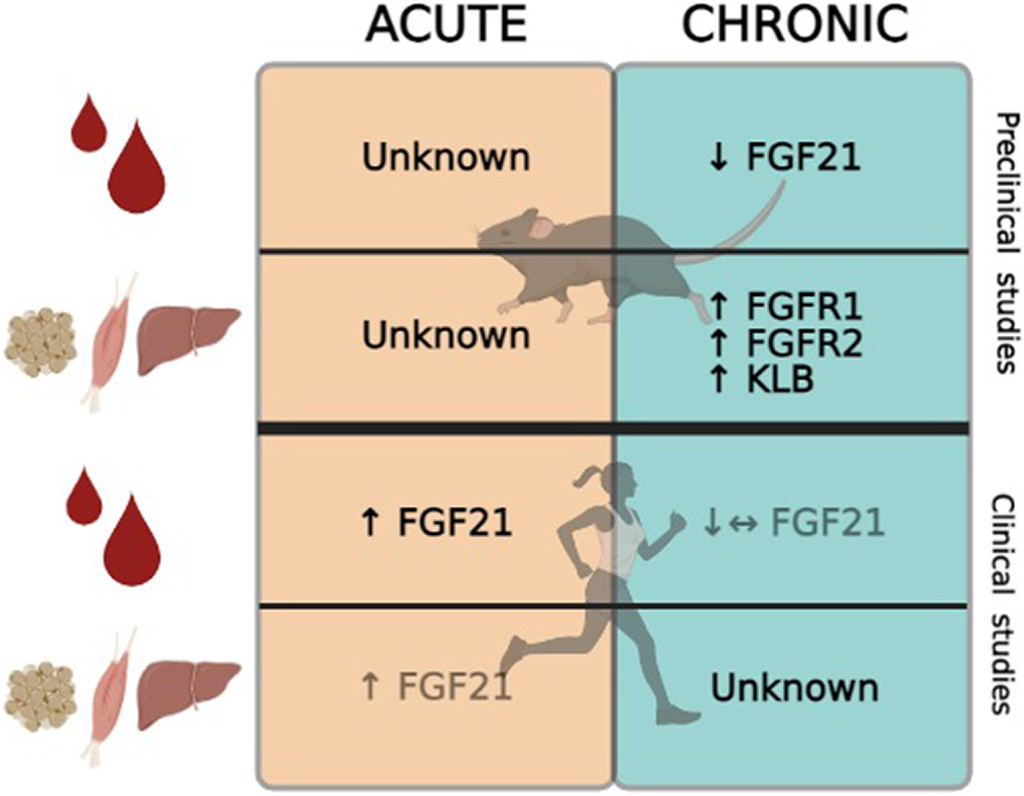

Fig. 3. Summary of the effects of aerobic exercise on ﬁbroblast growth factor 21 (FGF21),

its receptors, and co-receptor. The ﬁgure is divided by acute (left) and chronic (right)

effects of exercise on circulating (blood vessel) and tissue (adipose, muscle, and liver)

levels of FGF21, FGFRs, KLB, found in preclinical (upper half) and clinical (lower half)

studies. The faded text indicates that incipient data suggest that change. ↑: increase; ↓:

decrease; ↔: no change; FGFR1: ﬁbroblast growth factor receptor 1; FGFR2: ﬁbroblast

growth factor receptor 2; KLB: β-klotho. Figure created in BioRender.com.

Metabolism Clinical and Experimental 129 (2022) 155137

6

exercise-induced modiﬁcations to circulate levels of FGF21 are a way to

explain the beneﬁcial effects of exercise in preventing/delaying neuro-

degenerative disorders as well as the signalling pathways that regulate

these effects is a matter for investigation.

Moreover, when possible, potential effects of external interventions

(e.g. exercise) on FGF21 signalling should be studied considering both,

circulatory and tissue-speciﬁc levels of FGF21, along with its receptors

and co-receptor, to have a deeper understanding of the potential meta-

bolic effects of those interventions. Finally, it is worth considering that

most of the tissue-speciﬁc exercise-derived changes present here

were derived from studies conducted in animals (rats and mice), there-

fore these results should be carefully interpreted.

The strengths of this systematic review are related to the expansion

from only analyzing changes in the circulatory levels of FGF21 to its tran-

scriptional and translational changes in tissues, along with the effects of

exercise on FGF21 receptors and co-receptor, which are key for its biolog-

ical functions triggering, moreover, the differentiation between acute and

chronic effects of exercise also contributes to organize the information

available and identify the potential gaps in the ﬁeld. However, this review

has a few limitations due to variability in exercise prescriptions and the

heterogeneity in patient cohorts. These include that exercise prescription

differs signiﬁcantly in terms of intensity, duration, and frequency, hinder-

ing the possibility of extrapolating these ﬁndings into a broader scenario,

even more when some studies used physical activity (wheel running) as

opposed to a forced exercise regimen. Moreover, the age (from young to

almost older adults) and BMI of the participants (from slightly overweight

to severely obese >35 kg/m<sup>2</sup>) in the clinical studies also have wide vari-

ability, which could explain the lack of agreement between studies with

similar interventions. Even considering these weaknesses, the results pre-

sented here could be useful to further support the relevancy of

implementing aerobic exercise training programs for the management

of metabolic dysfunctions derived from overweight and obesity, even in

the absence of dietary interventions focused on body weight reduction/

normalization.

This is the ﬁrst known systematic review that aims to elucidate the

effects of aerobic exercise on FGF21 in a context of overweight/obesity,

which highlights the need for further efforts in the ﬁeld, considering

that the most consistent ﬁnding was located locally in active metabolic

tissues (e.g., liver, adipose tissue, skeletal muscle), instead of the circu-

latory levels of FGF21. Moreover, FGF21 receptors and co-receptor, in-

stead of FGF21 itself could be the factors that more actively react to

exercise, a hypothesis that needs further clariﬁcation in the future.

In conclusion, ﬁndings in clinical and preclinical studies support that

aerobic exercise exerts changes in circulatory and tissue FGF21, along

with its receptors and co-receptor. Interestingly, these responses are de-

pendent on the length of the intervention (acute vs chronic). Therefore,

this factor must be considered when studying the metabolic effects of

exercise, particularly in terms of FGF21 expression and signalling in

the context of overweight/obesity. Future studies should focus on test-

ing different exercise prescriptions (e.g., HIIT vs MICT) to ﬁnd which

subtype of aerobic exercise exerts the highest beneﬁts in subjects with

metabolic dysfunction.

Funding information

SM-H is supported by the National Agency of Research and

Development

(ANID)

through

an Early

Career

Research Grant

(FONDECYT de iniciación en investigación), code 11200391. PE is sup-

ported by the National Agency of Research and Development (ANID)

through a Research Grant (FONDECYT regular), code 1201635.

CRediT authorship contribution statement

Manuscript drafting: M.P.-R., V.G.-A., R.S.-V., S.M.-H. Editing and re-

vision of the manuscript: C.S.T., F.P., P.E., S.M.-H. Final version of manu-

script approved by: M.P.-R., V.G.-A., R.S.-V., C.S.T., F.P., P.E., S.M.-H.

Declaration of competing interest

The authors declare that they have no conﬂict of interest.

References

[1] Cercato C, Fonseca FA. Cardiovascular risk and obesity. Diabetol Metab Syndr. 2019;

11:74. https://doi.org/10.1186/s13098-019-0468-0.

[2] Zorena K, Jachimowicz-Duda O, Slezak D, Robakowska M, Mrugacz M. Adipokines

and obesity. Potential link to metabolic disorders and chronic complications. Int J

Mol Sci. 2020;21:3570. https://doi.org/10.3390/ijms21103570.

[3] Nishimura T, Nakatake Y, Konishi M, Itoh N. Identiﬁcation of a novel FGF, FGF-21,

preferentially expressed in the liver. Biochim Biophys Acta. 2000;1492:203–6.

https://doi.org/10.1016/s0167-4781(00)00067-1.

[4] Kharitonenkov A, Shiyanova TL, Koester A, Ford AM, Micanovic R, Galbreath EJ, et al.

FGF-21 as a novel metabolic regulator. J Clin Invest. 2005;115:1627–35. https://doi.

org/10.1172/JCI23606.

[5] Mashili FL, Austin RL, Deshmukh AS, Fritz T, Caidahl K, Bergdahl K, et al. Direct effects

of FGF21 on glucose uptake in human skeletal muscle: implications for type 2 diabe-

tes and obesity. Diabetes Metab Res Rev. 2011;27:286–97. https://doi.org/10.1002/

dmrr.1177.

[6] Kharitonenkov A, Adams AC. Inventing new medicines: the FGF21 story. Mol Metab.

2014;3:221–9. https://doi.org/10.1016/j.molmet.2013.12.003.

[7] Fisher FM, Maratos-Flier E. Understanding the physiology of FGF21. Annu Rev Phys-

iol. 2016;78:223–41. https://doi.org/10.1146/annurev-physiol-021115-105339.

[8] Yan J, Nie Y, Cao J, Luo M, Yan M, Chen Z, et al. The roles and pharmacological effects

of FGF21 in preventing aging-associated metabolic diseases. Front Cardiovasc Med.

2021. ;8:655575. https://doi.org/10.3389/fcvm.2021.655575.

[9] Tezze C, Romanello V, Sandri M. FGF21 as modulator of metabolism in health and

disease. Front Physiol. 2019;10:419. https://doi.org/10.3389/fphys.2019.00419.

[10] Ming AY, Yoo E, Vorontsov EN, Altamentova SM, Kilkenny DM, Rocheleau JV. Dy-

namics and distribution of klothobeta (KLB) and ﬁbroblast growth factor receptor-

1 (FGFR1) in living cells reveal the ﬁbroblast growth factor-21 (FGF21)-induced re-

ceptor complex. J Biol Chem. 2012;287:19997–20006. https://doi.org/10.1074/jbc.

M111.325670.

[11] Chen S, Chen ST, Sun Y, Xu Z, Wang Y, Yao SY, et al. Fibroblast growth factor 21 ame-

liorates neurodegeneration in rat and cellular models of Alzheimer's disease. Redox

Biol. 2019. ;22:101133. https://doi.org/10.1016/j.redox.2019.101133.

[12] de Oliveira Dos Santos AR, de Oliveira Zanuso B, Miola VFB, Barbalho SM, Santos

Bueno PC, Flato UAP. Adipokines, myokines, and hepatokines: crosstalk and meta-

bolic repercussions. Int J Mol Sci. 2021;22:2639. https://doi.org/10.3390/

ijms22052639.

[13] Domin R, Dadej D, Pytka M, Zybek-Kocik A, Ruchala M, Guzik P. Effect of various ex-

ercise regimens on selected exercise-induced cytokines in healthy people. Int J Envi-

ron Res Public Health. 2021;18:1261. https://doi.org/10.3390/ijerph18031261.

[14] Zhang X, Yeung DC, Karpisek M, Stejskal D, Zhou ZG, Liu F, et al. Serum FGF21 levels

are increased in obesity and are independently associated with the metabolic syn-

drome in humans. Diabetes. 2008;57:1246–53. https://doi.org/10.2337/db07-1476.

[15] Panahi Y, Bonakdaran S, Yaghoubi MA, Keramati MR, Haratian M, Sahebkar A. Serum

levels of ﬁbroblast growth factor 21 in type 2 diabetic patients. Acta Endocrinol

(Buchar). 2016;12:257–61. https://doi.org/10.4183/aeb.2016.257.

[16] Fisher FM, Chui PC, Antonellis PJ, Bina HA, Kharitonenkov A, Flier JS, et al. Obesity is a

ﬁbroblast growth factor 21 (FGF21)-resistant state. Diabetes. 2010;59:2781–9.

https://doi.org/10.2337/db10-0193.

[17] Markan KR. Deﬁning "FGF21 Resistance" during obesity: controversy, criteria and

unresolved questions. F1000Res. 2018;7:289. https://doi.org/10.12688/f1000re-

search.14117.1.

[18] Gallego-Escuredo JM, Gomez-Ambrosi J, Catalan V, Domingo P, Giralt M, Fruhbeck G,

et al. Opposite alterations in FGF21 and FGF19 levels and disturbed expression of the

receptor machinery for endocrine FGFs in obese patients. Int J Obes (Lond). 2015;39:

121–9. https://doi.org/10.1038/ijo.2014.76.

[19] Carbone S, Del Buono MG, Ozemek C, Lavie CJ. Obesity, risk of diabetes and role of

physical activity, exercise training and cardiorespiratory ﬁtness. Prog Cardiovasc

Dis. 2019;62:327–33. https://doi.org/10.1016/j.pcad.2019.08.004.

[20] Tanimura Y, Aoi W, Takanami Y, Kawai Y, Mizushima K, Naito Y, et al. Acute exercise

increases ﬁbroblast growth factor 21 in metabolic organs and circulation. Physiol

Rep. 2016. ;4:e12828. https://doi.org/10.14814/phy2.12828.

[21] Slusher AL, Whitehurst M, Zoeller RF, Mock JT, Maharaj M, Huang CJ. Attenuated ﬁ-

broblast growth factor 21 response to acute aerobic exercise in obese individuals.

Nutr Metab Cardiovasc Dis. 2015;25:839–45. https://doi.org/10.1016/j.numecd.

2015.06.002.

[22] Yang SJ, Hong HC, Choi HY, Yoo HJ, Cho GJ, Hwang TG, et al. Effects of a three-month

combined exercise programme on ﬁbroblast growth factor 21 and fetuin-a levels

and arterial stiffness in obese women. Clin Endocrinol (Oxf). 2011;75:464–9.

https://doi.org/10.1111/j.1365-2265.2011.04078.x.

[23] Besse-Patin A, Montastier E, Vinel C, Castan-Laurell I, Louche K, Dray C, et al. Effect of

endurance training on skeletal muscle myokine expression in obese men: identiﬁca-

tion of apelin as a novel myokine. Int J Obes (Lond). 2014;38:707–13. https://doi.

org/10.1038/ijo.2013.158.

[24] Garneau L, Parsons SA, Smith SR, Mulvihill EE, Sparks LM, Aguer C. Plasma myokine

concentrations after acute exercise in non-obese and obese sedentary women. Front

Physiol. 2020;11:18. https://doi.org/10.3389/fphys.2020.00018.

[25] Kong Z, Sun S, Liu M, Shi Q. Short-term high-intensity interval training on body com-

position and blood glucose in overweight and obese young women. J Diabetes Res.

2016. ;2016:4073618. https://doi.org/10.1155/2016/4073618.

Metabolism Clinical and Experimental 129 (2022) 155137

7

[26] Martinez-Huenchullan SF, Ban LA, Olaya-Agudo LF, Maharjan BR, Williams PF, Tam

CS, et al. Constant-moderate and high-intensity interval training have differential

beneﬁts on insulin sensitive tissues in high-fat fed mice. Front Physiol. 2019;10:

459. https://doi.org/10.3389/fphys.2019.00459.

[27] Sabaratnam R, Pedersen AJT, Kristensen JM, Handberg A, Wojtaszewski JFP, Hojlund

K. Intact regulation of muscle expression and circulating levels of myokines in re-

sponse to exercise in patients with type 2 diabetes. Physiol Rep. 2018. ;6:e13723.

https://doi.org/10.14814/phy2.13723.

[28] Sargeant JA, Aithal GP, Takamura T, Misu H, Takayama H, Douglas JA, et al. The inﬂu-

ence of adiposity and acute exercise on circulating hepatokines in normal-weight

and overweight/obese men. Appl Physiol Nutr Metab. 2018;43:482–90. https://doi.

org/10.1139/apnm-2017-0639.

[29] Fletcher JA, Meers GM, Laughlin MH, Ibdah JA, Thyfault JP, Rector RS. Modulating ﬁ-

broblast growth factor 21 in hyperphagic OLETF rats with daily exercise and caloric

restriction. Appl Physiol Nutr Metab. 2012;37:1054–62. https://doi.org/10.1139/

h2012-091.

[30] Hao L, Huang KH, Ito K, Sae-Tan S, Lambert JD, Ross AC. Fibroblast growth factor 21

(Fgf21) gene expression is elevated in the liver of mice fed a high-carbohydrate liq-

uid diet and attenuated by a lipid emulsion but is not upregulated in the liver of

mice fed a high-fat obesogenic diet. J Nutr. 2016;146:184–90. https://doi.org/10.

3945/jn.115.216572.

[31] Loyd C, Magrisso IJ, Haas M, Balusu S, Krishna R, Itoh N, et al. Fibroblast growth factor

21 is required for beneﬁcial effects of exercise during chronic high-fat feeding. J Appl

Physiol. 1985;2016(121):687–98. https://doi.org/10.1152/japplphysiol.00456.2016.

[32] Power Guerra N, Parveen A, Buhler D, Brauer DL, Muller L, Pilz K, et al. Fibroblast

growth factor 21 as a potential biomarker for improved locomotion and olfaction

detection ability after weight reduction in obese mice. Nutrients. 2021. ;13https://

doi.org/10.3390/nu13092916.

[33] Geng L, Liao B, Jin L, Huang Z, Triggle CR, Ding H, et al. Exercise alleviates obesity-

induced metabolic dysfunction via enhancing FGF21 sensitivity in adipose tissues.

Cell Rep. 2019. ;26(2738–52):e4. https://doi.org/10.1016/j.celrep.2019.02.014.

[34] Wang SS, Gu Q, Liu N, Li J, Liu X. Aerobic exercise attenuates ectopic renal sinus ad-

ipose tissue accumulation-related renal hypoxia injury in obese mice. Life Sci. 2021. ;

119106https://doi.org/10.1016/j.lfs.2021.119106.

[35] Xiong Y, Chen Y, Liu Y, Zhang B. Moderate-intensity continuous training improves

FGF21 and KLB expression in obese mice. Biochemistry (Mosc). 2020;85:938–46.

https://doi.org/10.1134/S000629792008009X.

[36] Yang W, Liu L, Wei Y, Fang C, Zhou F, Chen J, et al. Exercise ameliorates the FGF21-

adiponectin axis impairment in diet-induced obese mice. Endocr Connect. 2019;8:

596–604. https://doi.org/10.1530/EC-19-0034.

[37] Claycombe-Larson KJ, Bundy A, Lance EB, Darland DC, Casperson SL, Roemmich JN.

Postnatal exercise protects offspring from high-fat diet-induced reductions in subcu-

taneous adipocyte beiging in C57Bl6/J mice. J Nutr Biochem. 2021. ;99:108853.

https://doi.org/10.1016/j.jnutbio.2021.108853.

[38] Laeger T, Baumeier C, Wilhelmi I, Wurfel J, Kamitz A, Schurmann A. FGF21 improves

glucose homeostasis in an obese diabetes-prone mouse model independent of body

fat changes. Diabetologia. 2017;60:2274–84. https://doi.org/10.1007/s00125-017-

4389-x.

[39] Tok O, Kisioglu SV, Ersoz HO, Kahveci B, Goktas Z. Effects of increased physical activ-

ity and/or weight loss diet on serum myokine and adipokine levels in overweight

adults with impaired glucose metabolism. J Diabetes Complications. 2021. ;

35:107892. https://doi.org/10.1016/j.jdiacomp.2021.107892.

[40] Moure R, Cairo M, Moron-Ros S, Quesada-Lopez T, Campderros L, Cereijo R, et al.

Levels of beta-klotho determine the thermogenic responsiveness of adipose tissues:

involvement of the autocrine action of FGF21. Am J Physiol Endocrinol Metab. 2021;

320:E822–34. https://doi.org/10.1152/ajpendo.00270.2020.

[41] Cuevas-Ramos D, Mehta R, Aguilar-Salinas CA. Fibroblast growth factor 21 and

Browning of white adipose tissue. Front Physiol. 2019;10:37. https://doi.org/10.

3389/fphys.2019.00037.

[42] Abu-Odeh M, Zhang Y, Reilly SM, Ebadat N, Keinan O, Valentine JM, et al. FGF21 pro-

motes thermogenic gene expression as an autocrine factor in adipocytes. Cell Rep.

2021. ;35:109331. https://doi.org/10.1016/j.celrep.2021.109331.

[43] Singhal G, Kumar G, Chan S, Fisher FM, Ma Y, Vardeh HG, et al. Deﬁciency of ﬁbro-

blast growth factor 21 (FGF21) promotes hepatocellular carcinoma (HCC) in mice

on a long term obesogenic diet. Mol Metab. 2018;13:56–66. https://doi.org/10.

1016/j.molmet.2018.03.002.

[44] Dongiovanni P, Crudele A, Panera N, Romito I, Meroni M, De Stefanis C, et al. Beta-

klotho gene variation is associated with liver damage in children with NAFLD. J

Hepatol. 2020;72:411–9. https://doi.org/10.1016/j.jhep.2019.10.011.

[45] Somm E, Henry H, Bruce SJ, Aeby S, Rosikiewicz M, Sykiotis GP, et al. Beta-klotho de-

ﬁciency protects against obesity through a crosstalk between liver, microbiota, and

brown adipose tissue. JCI Insight. 2017. ;2:e91809. https://doi.org/10.1172/jci.in-

sight.91809.

[46] Chavez AO, Molina-Carrion M, Abdul-Ghani MA, Folli F, Defronzo RA, Tripathy D. Cir-

culating ﬁbroblast growth factor-21 is elevated in impaired glucose tolerance and

type 2 diabetes and correlates with muscle and hepatic insulin resistance. Diabetes

Care. 2009;32:1542–6. https://doi.org/10.2337/dc09-0684.

[47] Jeon JY, Choi SE, Ha ES, Kim TH, Jung JG, Han SJ, et al. Association between insulin

resistance and impairment of FGF21 signal transduction in skeletal muscles. Endo-

crine. 2016;53:97–106. https://doi.org/10.1007/s12020-015-0845-x.

[48] Kakoty V, CS K, Tang RD, Yang CH, Dubey SK, Taliyan R. Fibroblast growth factor 21

and autophagy: a complex interplay in Parkinson disease. Biomed Pharmacother.

2020. ;127:110145. https://doi.org/10.1016/j.biopha.2020.110145.

[49] Kang K, Xu P, Wang M, Chunyu J, Sun X, Ren G, et al. FGF21 attenuates neurodegen-

eration through modulating neuroinﬂammation and oxidant-stress. Biomed

Pharmacother. 2020. ;129:110439. https://doi.org/10.1016/j.biopha.2020.110439.

[50] Banitalebi E, Kazemi A, Faramarzi M, Nasiri S, Haghighi MM. Effects of sprint interval

or combined aerobic and resistance training on myokines in overweight women

with type 2 diabetes: a randomized controlled trial. Life Sci. 2019;217:101–9.

https://doi.org/10.1016/j.lfs.2018.11.062.

[51] Motahari Rad M, Bijeh N, Attarzadeh Hosseini SR, Raouf Saeb A. The effect of two

concurrent exercise modalities on serum concentrations of FGF21, irisin, follistatin,

and myostatin in men with type 2 diabetes mellitus. Arch Physiol Biochem. 2020;

1:10. https://doi.org/10.1080/13813455.2020.1829649.

Metabolism Clinical and Experimental 129 (2022) 155137

8